# Кластерный анализ

July 4-5, 2018

Поставим пакет Томаса:

```r
devtools::install_github('thomasp85/patchwork')
```

Подключим необходимые пакеты

```r
library(tidyverse) # обработка данных, графики...
library(skimr) # описательные статистики
library(rio) # импорт фантастического количества форматов данных

library(cluster) # кластерный анализ
library(factoextra) # визуализации kmeans, pca
library(dendextend) # визуализация дендрограмм
```

```r
library(corrplot) # визуализация корреляций
library(broom) # метла превращает результаты оценивания моделей в таблички

library(naniar) # визуализация пропущенных значений
library(visdat) # визуализация пропущенных значений

library(patchwork) # удобное расположение графиков рядом
library(factoextra) # визуализации kmeans, pca
library(corrplot) # визуализация корреляций
```

# 1 Кластеризация k-means

Возьмём микро данные по странам мира, которые подготовлены в SPSS. Загрузим их и посмотрим описательные статистики.

```r
country <- import('C:/Users/ASUS/Desktop/r_course/data/Macro_2.sav')
skim(country)
```

```
## Skim summary statistics
##  n obs: 35
##  n variables: 6
##
## -- Variable type:character ------------------------------------------------------------------------------
##  variable missing complete  n min max empty n_unique
##   Country       0       35 35   5  15     0       35
##
## -- Variable type:numeric --------------------------------------------------------------------------------
##      variable missing complete  n     mean       sd      p0      p25
##   Agricultura       0       35 35    39.07    18.81    2.7     23.26
##           GDP       0       35 35 36751.29 21653.08 9005.02 17775.28
##     Inflation       0       35 35     0.58     1.67   -1.74    -0.25
##          Life       0       35 35    77.83     2.96   69.7     76.95
##  Unemployment       0       35 35     8.44     5.04    3.4      5.8
##       p50      p75     p100     hist
##     44.14    53.21    71.3  ▃▃▃▁▇▇▅▃
##  36205.57 47236.55 1e+05    ▇▃▆▅▂▁▁▁
##      0.23     0.75     7.67 ▂▇▂▁▁▁▁▁
##     78.8     80.11    80.8  ▁▁▂▁▁▁▇▇
##      6.9      9.35    26.3  ▇▆▃▂▁▁▁▁
```

Отмасштабируем данные с помощью встроенной функции `scale()`. Поскольку она может работать только с числами, первый столбец `Country` ей передавать не нужно. Результат сохраним в таблице `country_stand`.

```r
country_stand <- mutate_if(country, is.numeric, ~ as.vector(scale(.)))
skim(country_stand)
```

```
## Skim summary statistics
##  n obs: 35
##  n variables: 6
##
## -- Variable type:character ------------------------------------------------------------------------------
##  variable missing complete  n min max empty n_unique
##   Country       0       35 35   5  15     0       35
##
## -- Variable type:numeric --------------------------------------------------------------------------------
##      variable missing complete  n     mean sd    p0   p25    p50   p75
##   Agricultura       0       35 35 -1.1e-16  1 -1.93 -0.84  0.27  0.75
##           GDP       0       35 35 -1.9e-18  1 -1.28 -0.88 -0.025 0.48
##     Inflation       0       35 35 -2.3e-17  1 -1.39 -0.5  -0.21  0.097
##          Life       0       35 35  1.5e-15  1 -2.75 -0.3   0.33  0.77
##  Unemployment       0       35 35 -1.7e-17  1 -1    -0.52 -0.31  0.18
##  p100     hist
##  1.71 ▃▃▃▁▇▇▅▃
##  2.99 ▇▃▆▅▂▁▁▁
##  4.25 ▂▇▂▁▁▁▁▁
##  1    ▁▁▂▁▁▁▇▇
##  3.55 ▇▆▃▂▁▁▁▁
```

Дополнение в виде функции `as.vector` нужно потому, что функция `scale` возвращает матрицу, а каждый столбец должен быть вектором :)

Выполним кластеризацию методом k-средних с помощью функции `kmeans`. Название страны не используется для кластеризации, но нужно для меток на графиках. Поэтому уберем столбец `Country` из набора данных и превратим его в метки строк.

В качестве аргументов укажем отмасштабированные данные `country_no_country` и количество кластеров `centers`. Пока мы не знаем, как выбирать оптимальное количество кластеров, поэтому предположим, что их три. Сохраним результат этого действия в список `k_means_country`.

```r
country_no_country <- country_stand %>% column_to_rownames(var = 'Country')
k_means_country <- kmeans(country_no_country, centers = 3)
k_means_country
```

```
## K-means clustering with 3 clusters of sizes 10, 3, 22
##
## Cluster means:
##          GDP   Inflation Unemployment       Life Agricultura
## 1 -0.8978337 -0.56522935    0.8841653 -0.9213815   0.2309281
## 2 -1.2116357  2.59862983   -0.3184546 -0.9603904   0.1567041
## 3  0.5733293 -0.09743618   -0.3584677  0.5497721  -0.1263361
##
## Clustering vector:
##       Australia         Austria         Belgium          Canada
##               3               3               3               3
##     Switzerland           Chile  Czech Republic         Germany
##               3               2               1               3
##         Denmark           Spain         Estonia         Finland
##               3               1               1               3
##          France  United Kingdom          Greece         Hungary
##               3               3               1               1
##         Ireland         Iceland          Israel           Italy
##               3               3               3               3
##           Japan     Korea, Rep.      Luxembourg          Latvia
##               3               3               3               1
##          Mexico     Netherlands          Norway     New Zealand
##               2               3               3               3
##          Poland        Portugal Slovak Republic        Slovenia
##               1               1               1               1
##          Sweden          Turkey   United States
##               3               2               3
##
## Within cluster sum of squares by cluster:
## [1] 35.915949  9.465746 51.446429
##  (between_SS / total_SS =  43.0 %)
##
## Available components:
##
## [1] "cluster"      "centers"      "totss"        "withinss"
## [5] "tot.withinss" "betweenss"    "size"         "iter"
## [9] "ifault"
```

Посмотрим на содержимое списка `k_means_country` командой `attributes()`.

```r
attributes(k_means_country)
```

```
## $names
## [1] "cluster"      "centers"      "totss"        "withinss"
## [5] "tot.withinss" "betweenss"    "size"         "iter"
## [9] "ifault"
##
## $class
## [1] "kmeans"
```

Посмотрим, например, на координаты центра кластеров или количество объектов в каждом из них.

```r
k_means_country$centers
```

```
##          GDP   Inflation Unemployment       Life Agricultura
## 1 -0.8978337 -0.56522935    0.8841653 -0.9213815   0.2309281
## 2 -1.2116357  2.59862983   -0.3184546 -0.9603904   0.1567041
## 3  0.5733293 -0.09743618   -0.3584677  0.5497721  -0.1263361
```

```r
k_means_country$cluster
```

```
##       Australia         Austria         Belgium          Canada
##               3               3               3               3
##     Switzerland           Chile  Czech Republic         Germany
##               3               2               1               3
##         Denmark           Spain         Estonia         Finland
##               3               1               1               3
##          France  United Kingdom          Greece         Hungary
##               3               3               1               1
##         Ireland         Iceland          Israel           Italy
##               3               3               3               3
##           Japan     Korea, Rep.      Luxembourg          Latvia
##               3               3               3               1
##          Mexico     Netherlands          Norway     New Zealand
##               2               3               3               3
##          Poland        Portugal Slovak Republic        Slovenia
##               1               1               1               1
##          Sweden          Turkey   United States
##               3               2               3
```

```r
k_means_country$size
```

```
## [1] 10  3 22
```

Другой способ структурировать вывод `kmeans` — использовать команду `tidy` из пакета `broom`.

```r
tidy(k_means_country)
```

```
##           x1          x2         x3         x4         x5 size  withinss
## 1 -0.8978337 -0.56522935  0.8841653 -0.9213815  0.2309281   10 35.915949
## 2 -1.2116357  2.59862983 -0.3184546 -0.9603904  0.1567041    3  9.465746
## 3  0.5733293 -0.09743618 -0.3584677  0.5497721 -0.1263361   22 51.446429
##   cluster
## 1       1
## 2       2
## 3       3
```

Визуализируем результаты.

Для этого будем использовать команду `fviz_cluster()` из пакета `factoextra`. Её аргументы — результат кластеризации `k_means_country`, исходные данные и ещё куча настроек вроде размера точек и цвета наблюдений-выбросов. Мы только попросим выделять цветом кластеры по их границам и укажем аргумент `ellipse.type = 'convex'`.

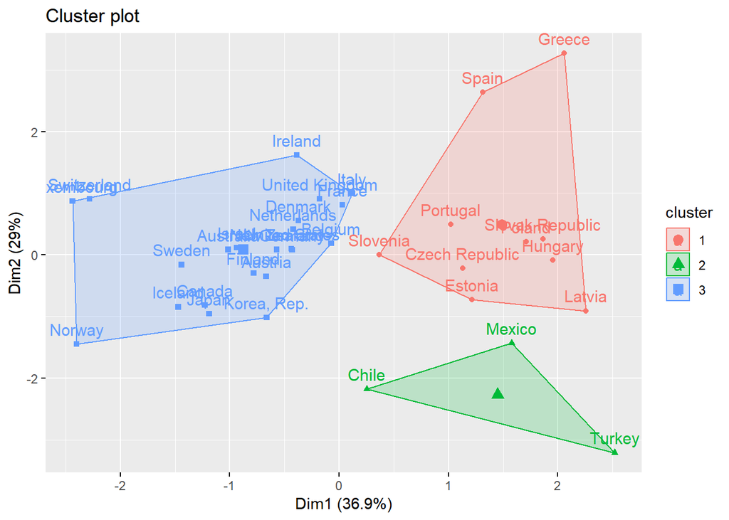

```r
fviz_cluster(object = k_means_country, data = country_no_country,
             ellipse.type = 'convex')
```

Кластеры достаточно хорошо различимы. Пересечения незначительные.

Предположим, что число кластеров - 2

```r
country_no_country <- country_stand %>% column_to_rownames(var = 'Country')
k_means_country <- kmeans(country_no_country, centers = 2)
k_means_country
```

```
## K-means clustering with 2 clusters of sizes 12, 23
##
## Cluster means:
##          GDP    Inflation Unemployment       Life Agricultura
## 1 -0.9612971 -0.009673368     0.690899 -1.0307419   0.3106733
## 2  0.5015463  0.005046974    -0.360469  0.5377784  -0.1620904
##
## Clustering vector:
##       Australia         Austria         Belgium          Canada
##               2               2               2               2
##     Switzerland           Chile  Czech Republic         Germany
##               2               2               1               2
##         Denmark           Spain         Estonia         Finland
##               2               1               1               2
##          France  United Kingdom          Greece         Hungary
##               2               2               1               1
##         Ireland         Iceland          Israel           Italy
##               2               2               2               2
##           Japan     Korea, Rep.      Luxembourg          Latvia
##               2               2               2               1
##          Mexico     Netherlands          Norway     New Zealand
##               1               2               2               2
##          Poland        Portugal Slovak Republic        Slovenia
##               1               1               1               1
##          Sweden          Turkey   United States
##               2               1               2
##
## Within cluster sum of squares by cluster:
## [1] 63.15369 60.08983
##  (between_SS / total_SS =  27.5 %)
##
## Available components:
##
## [1] "cluster"      "centers"      "totss"        "withinss"
## [5] "tot.withinss" "betweenss"    "size"         "iter"
## [9] "ifault"
```

Посмотрим на содержимое списка `k_means_country` командой `attributes()`.

```r
attributes(k_means_country)
```

```
## $names
## [1] "cluster"      "centers"      "totss"        "withinss"
## [5] "tot.withinss" "betweenss"    "size"         "iter"
## [9] "ifault"
##
## $class
## [1] "kmeans"
```

Посмотрим, например, на координаты центра кластеров или количество объектов в каждом из них.

```r
k_means_country$centers
```

```
##          GDP    Inflation Unemployment       Life Agricultura
## 1 -0.9612971 -0.009673368     0.690899 -1.0307419   0.3106733
## 2  0.5015463  0.005046974    -0.360469  0.5377784  -0.1620904
```

```r
k_means_country$cluster
```

```
##       Australia         Austria         Belgium          Canada
##               2               2               2               2
##     Switzerland           Chile  Czech Republic         Germany
##               2               2               1               2
##         Denmark           Spain         Estonia         Finland
##               2               1               1               2
##          France  United Kingdom          Greece         Hungary
##               2               2               1               1
##         Ireland         Iceland          Israel           Italy
##               2               2               2               2
##           Japan     Korea, Rep.      Luxembourg          Latvia
##               2               2               2               1
##          Mexico     Netherlands          Norway     New Zealand
##               1               2               2               2
##          Poland        Portugal Slovak Republic        Slovenia
##               1               1               1               1
##          Sweden          Turkey   United States
##               2               1               2
```

```r
k_means_country$size
```

```
## [1] 12 23
```

Другой способ структурировать вывод `kmeans` — использовать команду `tidy` из пакета `broom`.

```r
tidy(k_means_country)
```

```
##           x1           x2        x3         x4         x5 size withinss
## 1 -0.9612971 -0.009673368  0.690899 -1.0307419  0.3106733   12 63.15369
## 2  0.5015463  0.005046974 -0.360469  0.5377784 -0.1620904   23 60.08983
##   cluster
## 1       1
## 2       2
```

Визуализируем результаты. Для этого будем использовать команду `fviz_cluster()` из пакета `factoextra`. Её аргументы — результат кластеризации `k_means_country`, исходные данные и ещё куча настроек вроде размера точек и цвета наблюдений-выбросов. Мы только попросим выделять цветом кластеры по их границам и укажем аргумент `ellipse.type = 'convex'`.

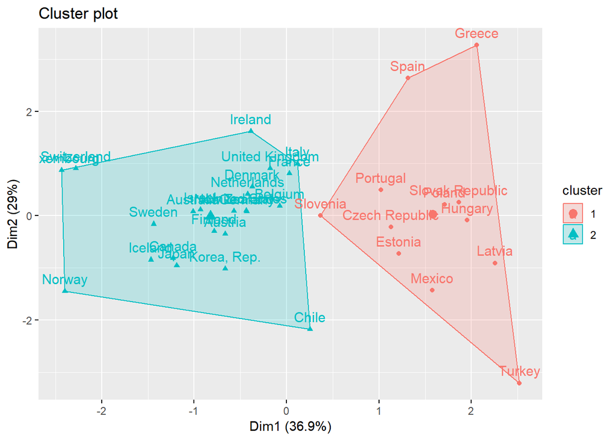

```r
fviz_cluster(object = k_means_country, data = country_no_country,
             ellipse.type = 'convex')
```

Кластеры хорошо различимы

Cколько кластеров оптимально? Один из способов сделать это — воспользоваться командой `fviz_nbclust` из пакета `factoextra`.

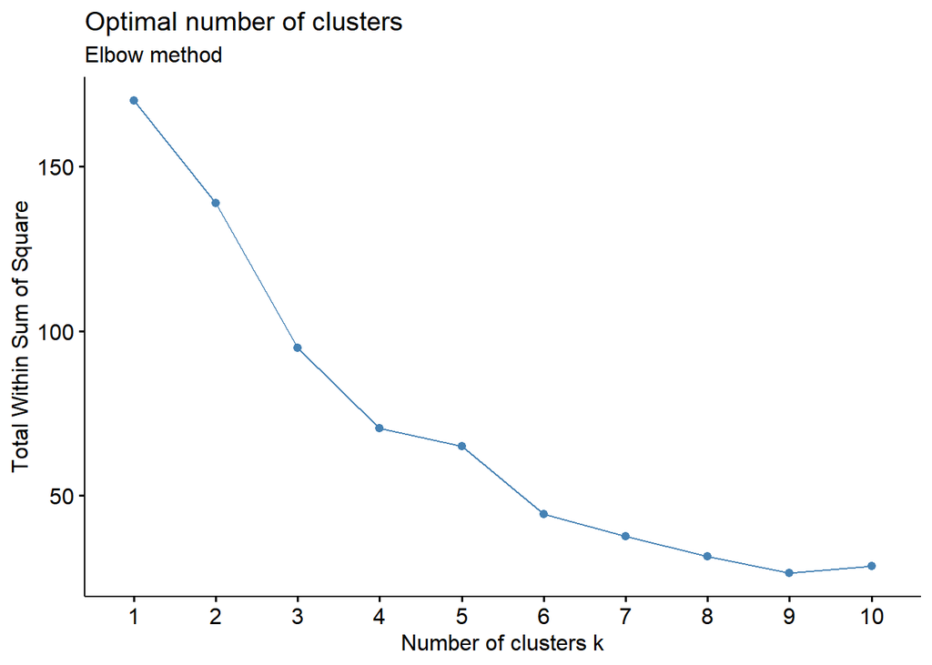

```r
g1 <- fviz_nbclust(country_no_country, kmeans, method = 'wss') +
  labs(subtitle = 'Elbow method')
g1
```

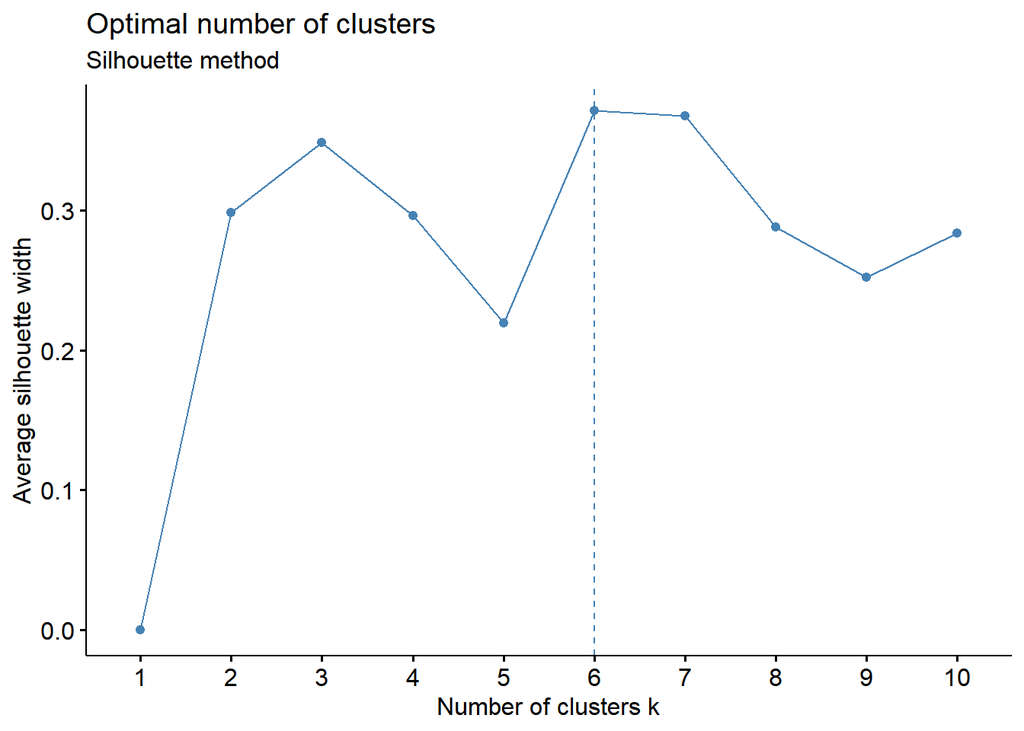

```r
g2 <- fviz_nbclust(country_no_country, kmeans, method = 'silhouette') +
  labs(subtitle = 'Silhouette method')
g2
```

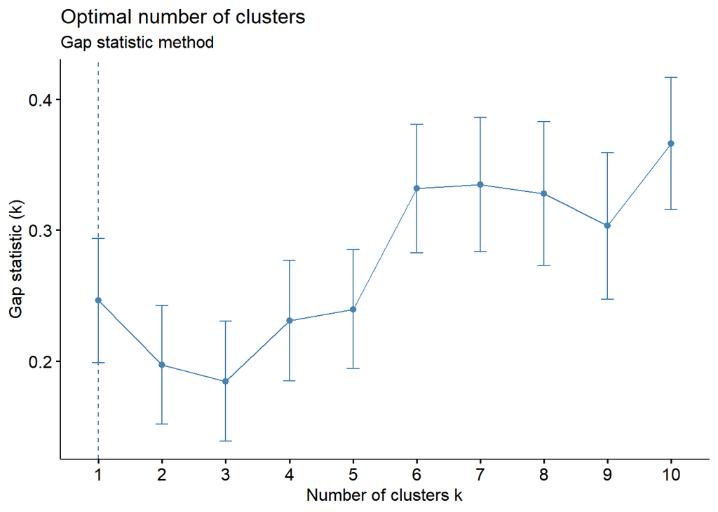

```r
g3 <- fviz_nbclust(country_no_country, kmeans, method = 'gap_stat') +
  labs(subtitle = 'Gap statistic method')
g3
```

Анализ результатов помогает увидеть, что оптимальное число кластеров может быть 3 или 6 (внршины на графике). 6 - это слишком большое число кластеров, которое отличается незначительными нюансами, поэтому целесообразно выделить 3 клатера.

С помощью хитрого пакета Томаса располагать графики легко! Попробуйте!

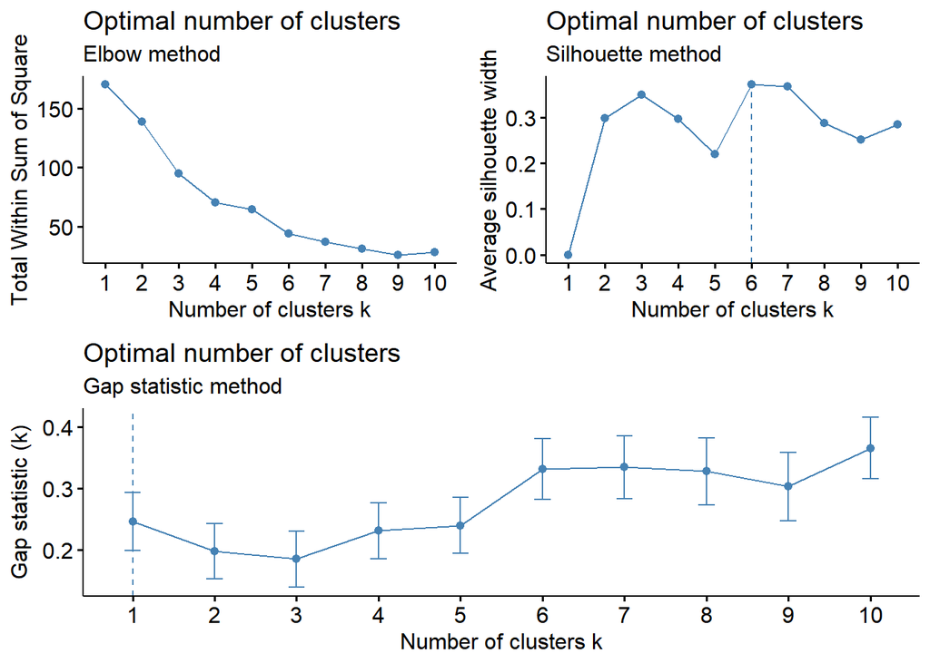

```r
(g1 + g2) / g3
```

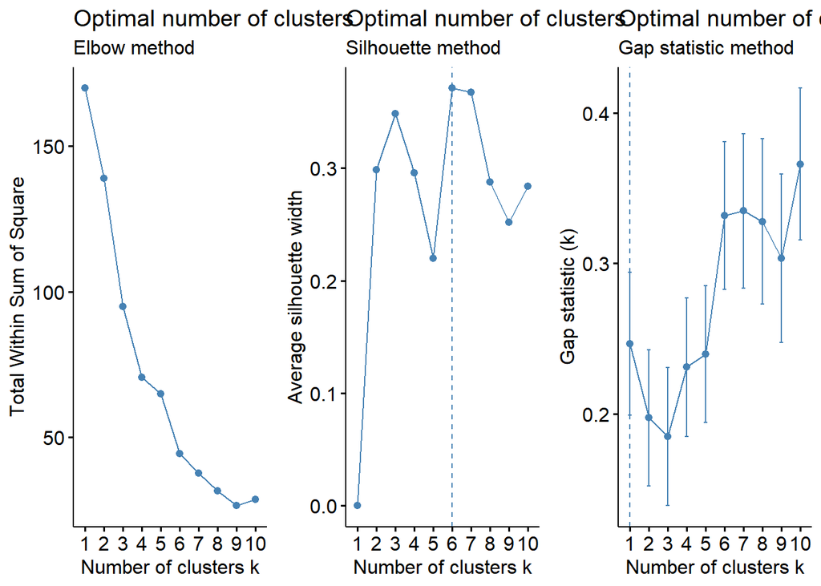

```r
g1 + g2 + g3
```

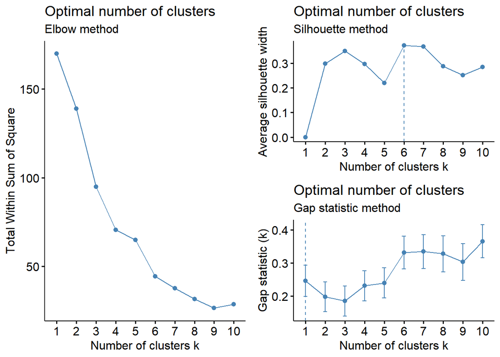

```r
g1 + (g2 / g3)
```

Метки кластерам легко добавить к исходным данным:

```r
country_plus <- mutate(country, cluster = k_means_country$cluster)
glimpse(country_plus)
```

```
## Observations: 35
## Variables: 7
## $ Country      <chr> "Australia", "Austria", "Belgium", "Canada", "Swi...
## $ GDP          <dbl> 56310.963, 43774.985, 40324.028, 43248.530, 80945...
## $ Inflation    <dbl> 1.50836672, 0.89656616, 0.56059398, 1.12524136, -...
## $ Unemployment <dbl> 6.0, 5.0, 8.5, 6.9, 4.5, 6.4, 6.2, 5.0, 6.6, 24.7...
## $ Life         <dbl> 80.300, 78.800, 78.100, 80.021, 80.800, 78.644, 7...
## $ Agricultura  <dbl> 51.627156, 38.221638, 44.138045, 7.175557, 38.609...
## $ cluster      <int> 2, 2, 2, 2, 2, 2, 1, 2, 2, 1, 1, 2, 2, 2, 1, 1, 2...
```

# 2 Иерархическая кластеризация

Другой способ разбить данные на группы — иерархическая кластеризация. Но, в отличие от метода k-средних, она работает с матрицей расстояний, поэтому первым делом посчитаем её! Для этого будем использовать функцию `dist()`. Передадим ей стандартизированные данные и укажем явно, как считать расстояния с помощью аргумента `method`.

```r
country_dist <- dist(country_no_country, method = 'euclidian')
```

Визуализируем расстояния с помощью команды `fviz_dist` из пакета `factoextra`.

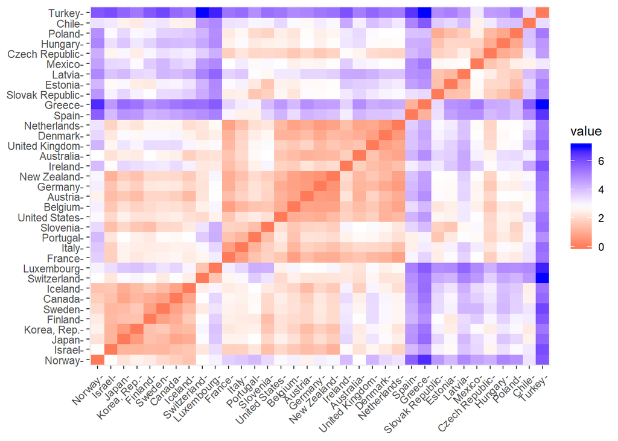

```r
fviz_dist(country_dist)
```

Полученную матрицу расстояний можно передадать функции `hclust()`, которая кластеризует данные. Однако в пакете `factoextra` есть функция `hcut()`, которая работает с исходными данными. Будем использовать её и попросим выделить 4 кластера в аргументе `k`.

```r
country_hcl <- hcut(country_no_country, k = 4)
```

С помощью функции `fviz_dend` визуализируем результат кластеризации. Укажем несколько аргументов, чтобы сделать дендрограмму красивее, (полный перечень можно посмотреть в справке). Согласно построенным дендрограммам наилучшее разбиение объектов на 4 кластера.

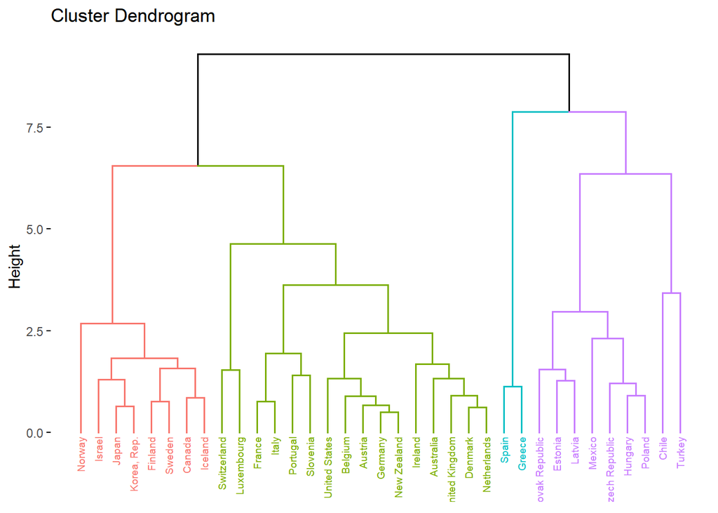

```r
fviz_dend(country_hcl,
          cex = 0.5, # размер подписи
          color_labels_by_k = TRUE) # цвет подписей по группам
```

Выявленные кластеры можно добавить к исходным данным!

```r
country_plus2 <- mutate(country, cluster = country_hcl$cluster)
glimpse(country_plus2)
```

```
## Observations: 35
## Variables: 7
## $ Country      <chr> "Australia", "Austria", "Belgium", "Canada", "Swi...
## $ GDP          <dbl> 56310.963, 43774.985, 40324.028, 43248.530, 80945...
## $ Inflation    <dbl> 1.50836672, 0.89656616, 0.56059398, 1.12524136, -...
## $ Unemployment <dbl> 6.0, 5.0, 8.5, 6.9, 4.5, 6.4, 6.2, 5.0, 6.6, 24.7...
## $ Life         <dbl> 80.300, 78.800, 78.100, 80.021, 80.800, 78.644, 7...
## $ Agricultura  <dbl> 51.627156, 38.221638, 44.138045, 7.175557, 38.609...
## $ cluster      <int> 1, 1, 1, 2, 1, 3, 3, 1, 1, 4, 3, 2, 1, 1, 4, 3, 1...
```

Иерархичская кластеризация полезна и для визуализаций корреляций. Если в функции `corrplot()` из одноимённого пакета указать аргумента `order = hclust`, то мы получим сгруппированные по кластерам переменные. Для красоты добавим ещё один аргумент — `addrect = 4`. Он обведёт прямоугольниками указанное число кластеров.

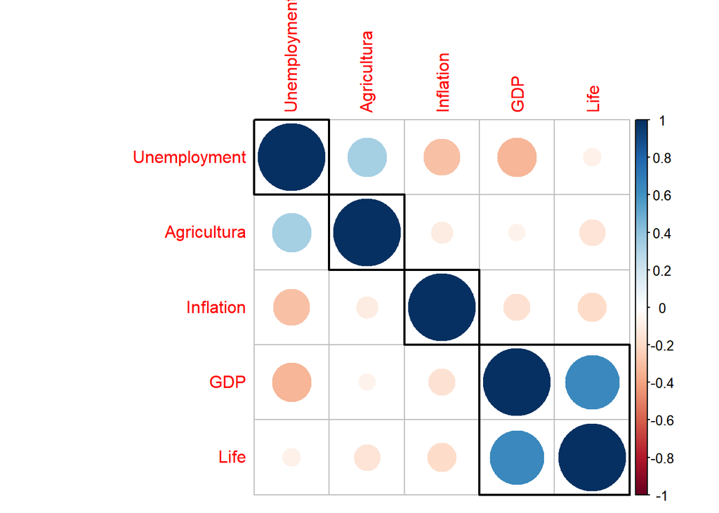

```r
country_cor <- cor(country_no_country)
corrplot(country_cor, order = 'hclust', addrect = 4)
```

# 3 МЕТОД ГЛАВНЫХ КОМПОНЕНТ

Примените метод главных компонент к набору данных о странах и затем визуализируем результат в осях первых двух главных компонент.

```r
country_pca <- prcomp(country_no_country)
country_pca
```

```
## Standard deviations (1, .., p=5):
## [1] 1.3584663 1.2051269 0.9113141 0.7802182 0.5128396
##
## Rotation (n x k) = (5 x 5):
##                     PC1        PC2         PC3        PC4        PC5
## GDP          -0.6371405  0.1859537 -0.29472846  0.1101172 -0.6785886
## Inflation     0.0741660 -0.6363896 -0.47081404 -0.5911762 -0.1354717
## Unemployment  0.3943032  0.5407506  0.19300563 -0.5941648 -0.4022820
## Life         -0.5860564  0.2975310 -0.02230291 -0.5042941  0.5596456
## Agricultura   0.2993563  0.4236669 -0.80852996  0.1761833  0.2147811
```

```r
country_pca$sdev
```

```
## [1] 1.3584663 1.2051269 0.9113141 0.7802182 0.5128396
```

Посмотрим, что лежит в списке

```r
attributes(country_pca)
```

```
## $names
## [1] "sdev"     "rotation" "center"   "scale"    "x"
##
## $class
## [1] "prcomp"
```

Главные компоненты лежат в матрице country_pca$x Посмотрим на первую ГК

```r
country_pca$x[, 1]
```

```
##       Australia         Austria         Belgium          Canada
##     -1.01407994     -0.66679636     -0.07325543     -1.22857216
##     Switzerland           Chile  Czech Republic         Germany
##     -2.28079027      0.25020332      1.12924306     -0.43005552
##         Denmark           Spain         Estonia         Finland
##     -0.37319118      1.31276811      1.21236686     -0.78199522
##          France  United Kingdom          Greece         Hungary
##      0.03028386     -0.17822355      2.05824749      1.95349734
##         Ireland         Iceland          Israel           Italy
##     -0.38693619     -1.47045899     -0.93501909      0.12064961
##           Japan     Korea, Rep.      Luxembourg          Latvia
##     -1.18832249     -0.66283393     -2.43755998      2.25372421
##          Mexico     Netherlands          Norway     New Zealand
##      1.57592315     -0.42036720     -2.39994625     -0.56952214
##          Poland        Portugal Slovak Republic        Slovenia
##      1.70770075      1.02009326      1.86348671      0.36753204
##          Sweden          Turkey   United States
##     -1.44095019      2.52056718     -0.43741086
```

Выборочные стандартные отклоненения лежат в векторе country_pca$sdev

```r
country_pca$sdev
```

```
## [1] 1.3584663 1.2051269 0.9113141 0.7802182 0.5128396
```

Визуализируем исходные данные на осях ГК. Для этого необходима функция fviz_pca_ind() из пакета factoextra. Рисовать будем country_pca, а аргумент repel = TRUE укажем для того, чтобы подписи на графике не перекрывали друг друга

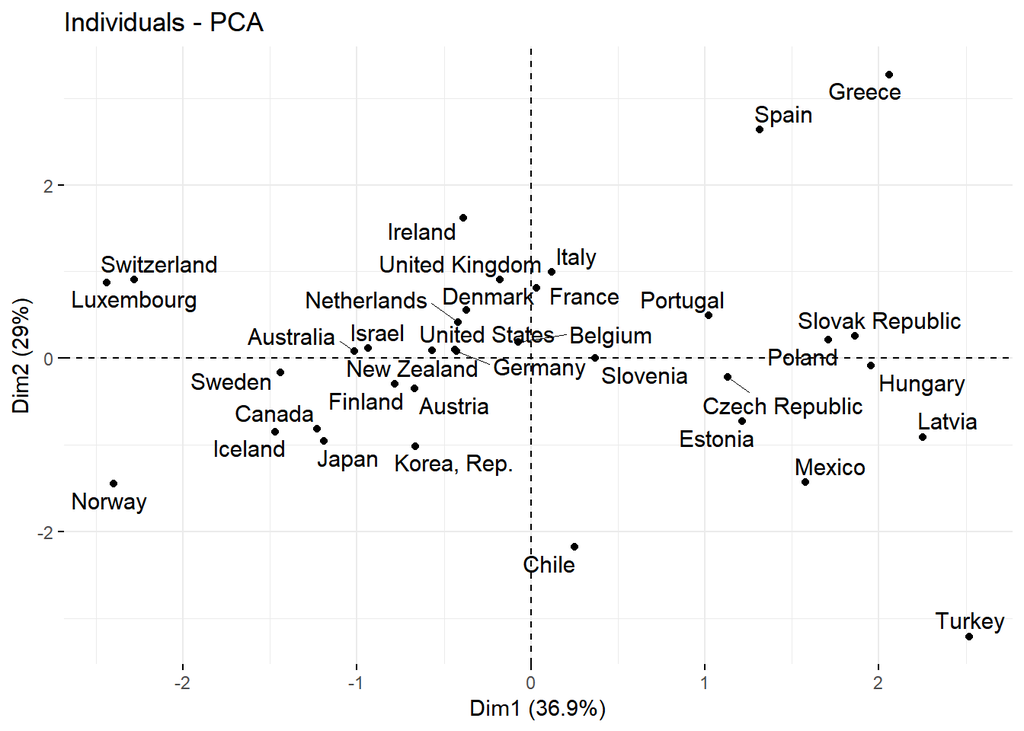

```r
fviz_pca_ind(country_pca, repel = TRUE)
```

Первая главная компонента смогла объяснить только 36.9% разброса даныых, вторая - 29. Таким образом, на первые две ГК приходится 65,9% вариации исходного признакового пространства.

Взглянем на все выделенные ГК

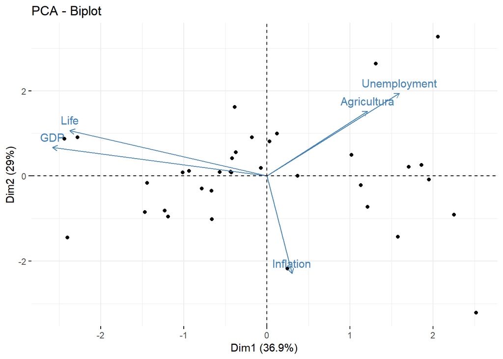

```r
fviz_pca_biplot(country_pca, geom.ind = 'point')
```

Визуализируйте вклад каждой переменной в первую главную компоненту.

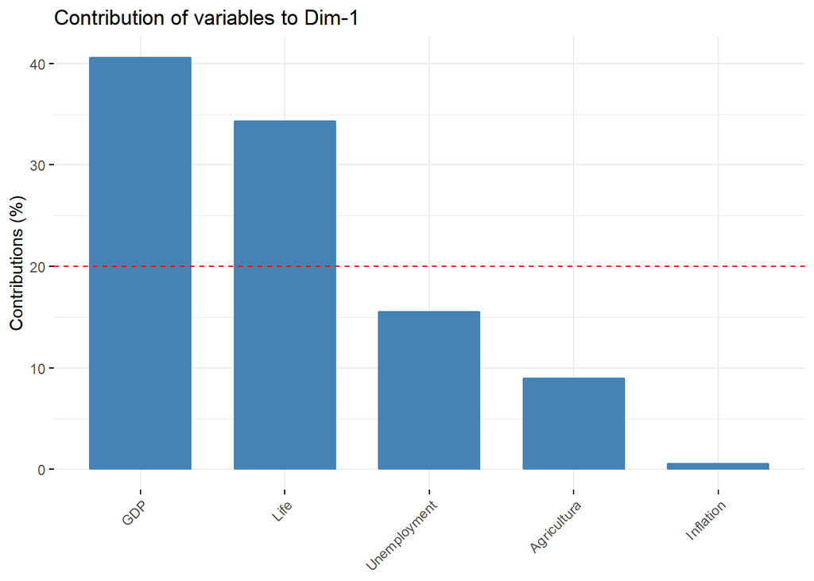

```r
fviz_contrib(country_pca, choice = 'var', axes = 1)
```

Таким образом, максимальный вклад в превую ГК у пеерменных GDP, Life. Их вклад в первую главную компоненту можно считать значительным.

Визуализируйте вклад каждой переменной во вторую главную компоненту.

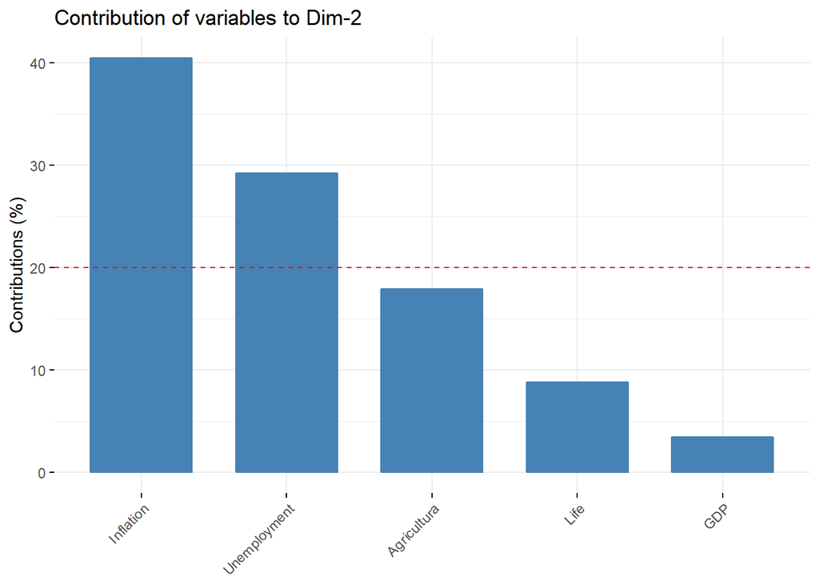

```r
fviz_contrib(country_pca, choice = 'var', axes = 2)
```

Таким образом, максимальный вклад во вторую ГК у пеерменных Inflation, Unemployment. Их вклад во вторую главную компоненту можно считать значительным.

Нарисуем проекции исходных переменных в осях первых двух главных компонент. Функции `fviz_pca_biplot` передадим аргумент, который делает подписи аккуратными.

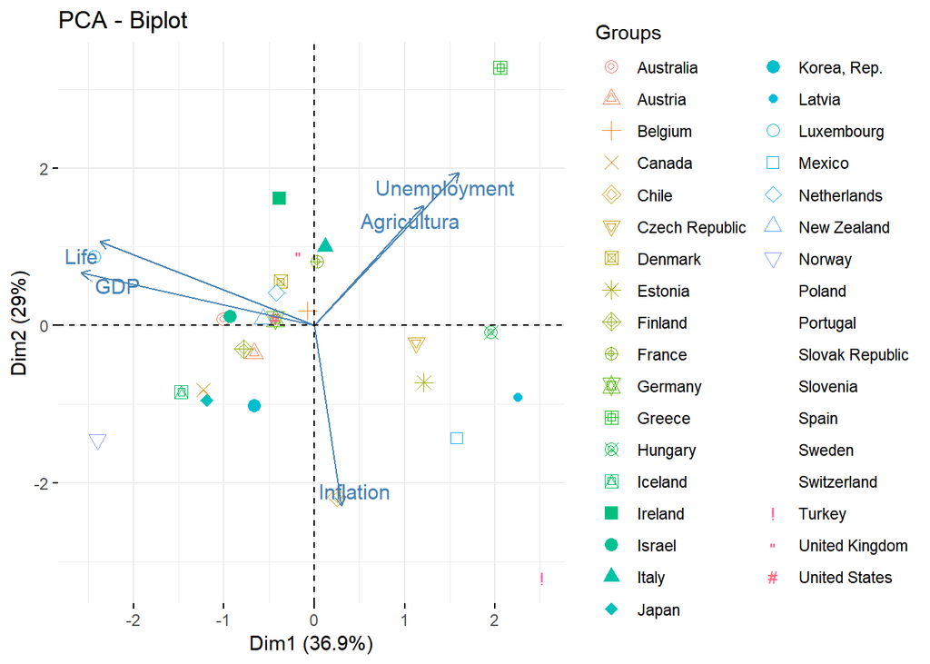

```r
fviz_pca_biplot(country_pca, geom.ind = 'point', habillage = country$Country, repel = TRUE)
```

Визуализируйте процент разброса, который объясняет каждая главная компонента и добавим эти значения на график.

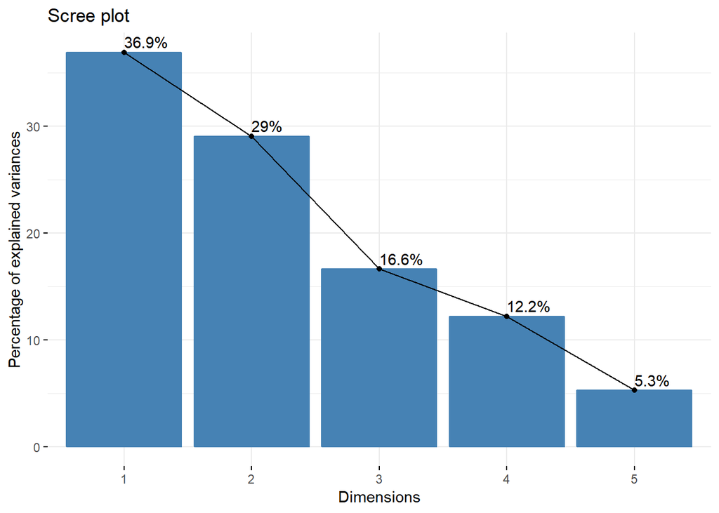

```r
fviz_eig(country_pca, addlabels = TRUE)
```

Ура! :)